# Mock exam

Inventory Management

Thomas Kirschstein

# Task 1: MRP

The company “DeEffimero” is a producer of coffee machines and faces a cyber attack (presumably from a competitor). The attack causes severe damage in the MRP system. Therefore, all planning processes have to ben done by hand. Luckily, the customer demands and inventory levels for the next week have been printed out. Therefore, it is known that for the two main products “Magnifico” (Mag) and “Professione” (Pro) total orders of 31 and 22 are given. Inventory records for the raw materials (R1,…,R4) and components (C1,…,C3) are as follows:

| material id | R1 | R2 | R3 | R4 | C1 | C2 | C3 |
| --- | --- | --- | --- | --- | --- | --- | --- |
| inventory level | 125 | 163 | 225 | 183 | 47 | 95 | 41 |

Information about the assembly processes are scattered. The only surviving piece of information is the following deranged matrix of direct production coefficients:

```
##     R1 Mag Pro C1 C3 R4 C2 R3 R2
## C1   0   1   3  0  0  0  0  0  0
## R1   0   3   0  5  3  0  4  0  0
## R4   0   0   3  2  5  0  3  0  0
## Pro  0   0   0  0  0  0  0  0  0
## R3   0   1   3  0  2  0  6  0  0
## C3   0   0   0  1  0  0  0  0  0
## R2   0   1   0  3  1  0  2  0  0
## Mag  0   0   0  0  0  0  0  0  0
## C2   0   1   0  2  2  0  0  0  0
```

1. Help the management and draw a tree graph of the production process. Determine the production stages of each material. (*10 points*)

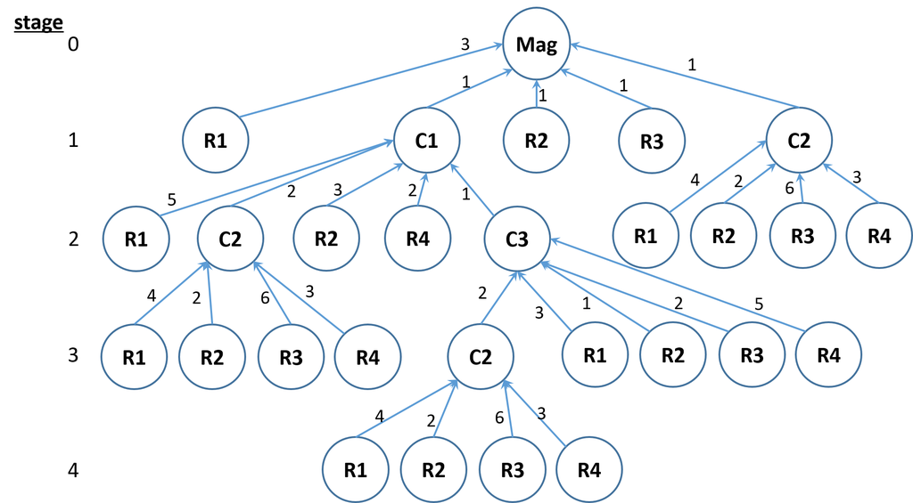

[figure not shown]

The production stages are

| material id | R1 | R2 | R3 | R4 | C1 | C2 | C3 |
| --- | --- | --- | --- | --- | --- | --- | --- |
| prod. stage | 4 | 4 | 4 | 4 | 1 | 3 | 2 |

2. Deduce the Gozinto graph of the production process and calculate the net demand of all materials. (*15 points*)

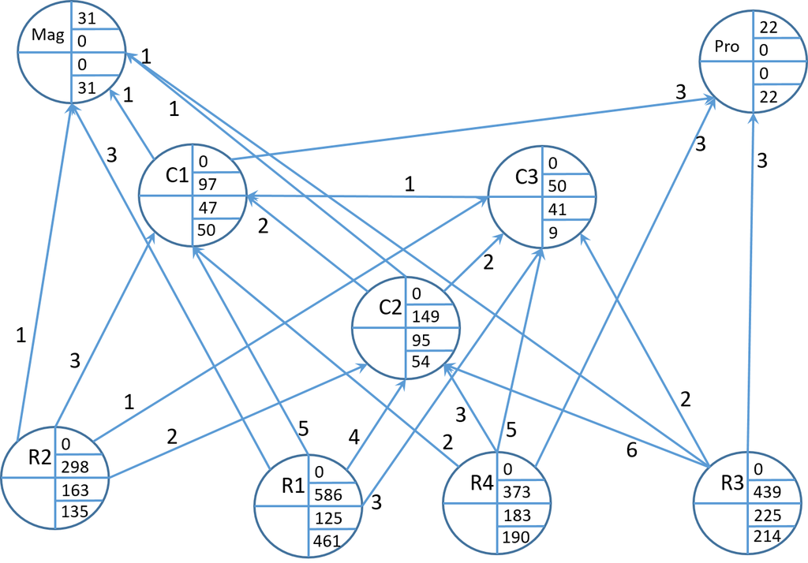

# Task 2: Forecasting

Procurement processes at “DeEffimero” are typically highly automized. Particularly, the forecasts of C-material demands are usually automatically submitted to the corresponding raw material suppliers. However, due to the system break down the procurement manager has to calculate the forecasts by hand. For raw material R3 the following weekly demands have been found in the remnants of the MRP system:

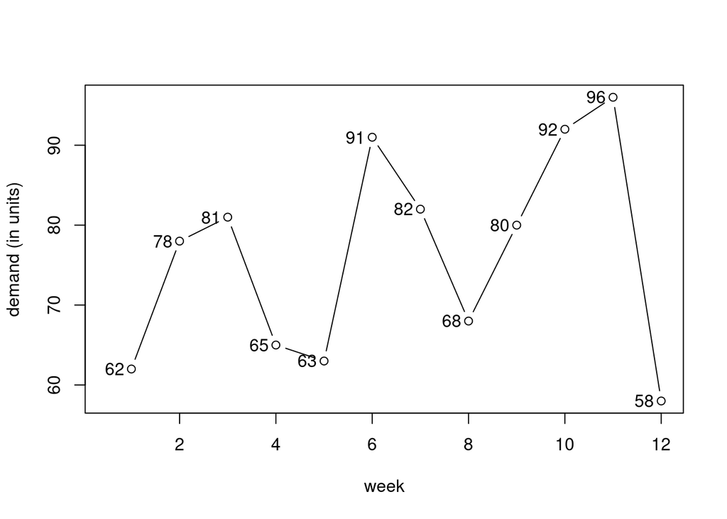

1. In first trial, the procurement manager intends to forecasts the demand of week 13 with simple moving average with $n=4$ week. Calculate the forecast of week 13 and forecast errors for the previous weeks. Add the forecasts to the diagram and calculate the root mean squared error (RMSE) for this forecasting method. (*10 points*)

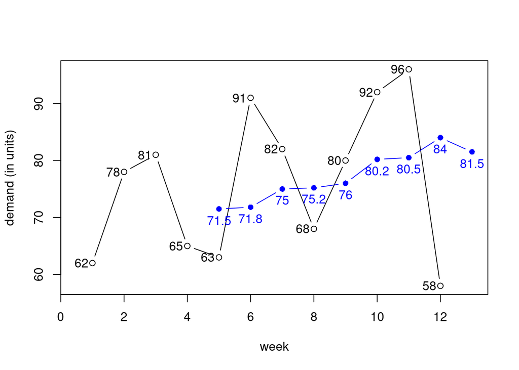

2. The procurement manager perceives the RMSE of the simple moving average forecasts as too high. She tries to improve the forecasts by applying 2nd order exponential smoothing with $\alpha = 0.5$ and $\beta = 0.5$ as well as $a_0 = 60$ and $b_0=1$. Calculate the forecast for week 13 and the RMSE for this method. (*10 points*)
3. Do you think the procedure outlined in 2. is best suited for forecasting the time series? What could be done to find better forecasts? (*5 points*)

Probably, the forecasting accuracy can be improved by a) tuning the parameters of forecasting methods ($\alpha$, $\beta$, initial values, …) and b) a more sophisticated forecasting model. As the time series seems to show a cyclic pattern possibly 3rd order exponential smoothing or an seasonal ARIMA model would deliver better forecasting results.

Hint: Round to 1 digit in all calculations of task 2.

# Task 3: ($s$,$q$) optimization

For raw material “R1” an ($s$,$q$) policy is pursued. The sole supplier charges 250 Euro for each order placed. The raw material has a unit price of 1.50 Euro and the “DeEffimero” calculates with a holding cost rate of 1% per Euro and week. The procurement manager remembers that the supplier is quite reliable and delivers orders within 2 weeks once an order is placed. Additionally, she expects the weekly demand to be independent and normally distributed with $\mu=50$ and $\sigma=25$.

1. What is the risk period in this case? How is the demand in the risk period distributed? (*5 points*)

The risk periods equals the order lead time and is 2 weeks. The risk period demand (i.e., the demand duing two weeks) is independently normally distributed with $Y^{RP} \sim N\left(2 \cdot 50, 2\cdot25^2 \right)$.

2. Calculate the optimal values of $s$ and $q$ when the procurement manager intends to achieve a $\beta$ service level of $98$%. (*15 points*)

Set $c^{sh}=0.01\cdot 1.5 = 0.015$ and $c^{or} = 250$

```
##       iter          q         ef          s     lambda
##    1.00000 1290.99445   25.81989   80.67983   27.36611
##       iter          q         ef          s     lambda
##    2.00000 1326.98103   26.53962   79.66969   27.74703
##       iter          q         ef          s     lambda
##    3.00000 1328.47761   26.56955   79.62798   27.76289
##       iter          q         ef          s     lambda
##    4.00000 1328.54043   26.57081   79.62623   27.76355
##       iter          q         ef          s     lambda
##    5.00000 1328.54307   26.57086   79.62615   27.76358
##       iter          q         ef          s     lambda
##    6.00000 1328.54318   26.57086   79.62615   27.76358
```

```
## [1]   79.62615 1328.54318
```

–> Using the tabulated values you would step at iteration 3

3. How do you assess the appropriateness of the outlined procedure? What aspects could be reconsidered to improve the results? (*5 points*)

Under the given information, the procedure seems to be appropriate. However, if the $\beta$ service level should be that very high, it is probably worthwhile to analyze the lead time more closely such that variations in the lead time can included in the safety stock calculation.

# Task 4: Joint Economic Lot Sizing

The components C1 to C6 are all produced on the same machine. The production manager thinks about switching to a make-to-stock production for these components due to the IT system break-down. The production-specific information are summarized as follows:

| component | C1 | C2 | C3 | C4 | C5 | C6 |
| --- | --- | --- | --- | --- | --- | --- |
| holding cost rate $c^{sh}_i$ | 0.01 | 0.05 | 0.1 | 0.25 | 0.02 | 0.08 |
| setup cost $c^{or}_i$ | 120 | 250 | 85 | 375 | 200 | 110 |
| demand rate $y_i$ | 70 | 25 | 55 | 30 | 95 | 100 |
| production rate $p_i$ | 400 | 300 | 380 | 350 | 650 | 500 |
| setup time $s_i$ | 0.2 | 0.5 | 0.3 | 0.1 | 0.2 | 0.1 |

1. Calculate the independent solution and the associated total cost. Is this solution feasible? (*10 points*)

The independent solution is calculated as $T_i = \sqrt{\frac{2\cdot c^{or}_i}{c^{sh}_i \cdot y_i \cdot (1-\rho_i)} }$

2. Find a feasible solution with power-of-2 heuristic. What are the total cost of this solution? (*15 points*)
- *1st iteration*

As $B=$ 5.7 no feasible sequence can be found.

Thus, we reduce the multiplier for the product with the largest batch time $\Rightarrow \; m_1= 2$

- *2nd iteration*

As $B=$ 6 and due to the large batch time of product 2 no feasible solution can be found

Thus, we reduce the multiplier of product 2 $\Rightarrow \; m_2= 2$

- *3rd iteration*

The total cost is 205.1